# Running Basic Multilevel Models in R with `lme4`

# 5. Run the Random-Coefficients Model

## Model Equation

Lv-1:

$$\texttt{mathach}_{ij} = \beta_{0j} + \beta_{1j} \texttt{ses}_{ij} + e_{ij}$$

Lv-2:

$$\begin{align*}
\beta_{0j} & = \gamma_{00} + \gamma_{01} \texttt{meanses}_j + u_{0j} \\
\beta_{1j} & = \gamma_{10} + u_{1j}
\end{align*}$$
The additional term is $u_{1j}$, which represents the deviation of the slope of school $j$ from the average slope (i.e., $\gamma_{10}$).

## Running in R

We have to put `ses` in the random part:

```r
ran_slp <- lmer(mathach ~ meanses + ses + (ses | id), data = hsball)
```

Alternatively, you can also use the `update` function.

You can summarize the results using

```r
summary(ran_slp)
```

```
Linear mixed model fit by REML ['lmerMod']
Formula: mathach ~ meanses + ses + (ses | id)
   Data: hsball

REML criterion at convergence: 46561.4

Scaled residuals:
    Min      1Q  Median      3Q     Max
-3.1671 -0.7270  0.0163  0.7547  2.9646

Random effects:
 Groups   Name        Variance Std.Dev. Corr
 id       (Intercept)  2.6953  1.6417
          ses          0.4531  0.6731   -0.21
 Residual             36.7956  6.0659
Number of obs: 7185, groups:  id, 160

Fixed effects:
            Estimate Std. Error t value
(Intercept)  12.6513     0.1506  84.000
meanses       3.7812     0.3826   9.883
ses           2.1903     0.1218  17.976

Correlation of Fixed Effects:
        (Intr) meanss
meanses -0.028
ses     -0.080 -0.256
```

## Testing Variance Components

In R, it’s easy compare two nested models (e.g., the decomposing effect model and the random-coefficients model) with the likelihood ratio test. All you should do is to use the `anova` function, and then **divide the *p* value by two**. Note, however, that `lme4` will refit the models using *maximum likelihood (ML)*, instead of *restricted maximum likelihood* (*REML*; the default), so the test results may be slightly different from computing the test statistic using HLM or SPSS by hand.

As an example,

```r
# With `lme4`
anova(ran_slp, decompose)
```

[output not shown]

## Plotting Random Slopes

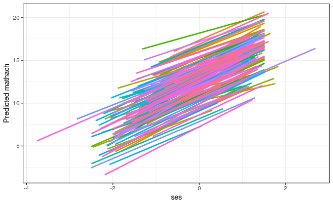

```r
# Get the predicted values for plotting from `lme4`
predict_ran_slp <- hsball %>% select(id, ses) %>% mutate(fit = predict(ran_slp))

ggplot(data = predict_ran_slp, aes(x = ses, y = fit, color = factor(id))) +
  geom_smooth(method = "lm", se = FALSE) +
  labs(y = "Predicted mathach") +
  guides(color = FALSE)
```

# 6. Analyzing Cross-Level Interactions

`sector` is added to the level-2 intercept and slope equations

## Model Equation

Lv-1:

$$\texttt{mathach}_{ij} = \beta_{0j} + \beta_{1j} \texttt{ses}_{ij} + e_{ij}$$

Lv-2:

## Running in R

We have to put the `sector * ses` interaction to the fixed part:

```r
crlv_int <- lmer(mathach ~ meanses + sector * ses + (ses | id),
                 data = hsball)
```

Alternatively, you can also use the `update` function.

```r
crlv_int <- update(ran_slp, . ~ . + sector * ses)
```

You can summarize the results using

```r
summary(crlv_int)
```

```
Linear mixed model fit by REML ['lmerMod']
Formula: mathach ~ meanses + sector * ses + (ses | id)
   Data: hsball

REML criterion at convergence: 46514.1

Scaled residuals:
     Min       1Q   Median       3Q      Max
-3.09724 -0.73034  0.01798  0.75423  3.04156

Random effects:
 Groups   Name        Variance Std.Dev. Corr
 id       (Intercept)  2.33993 1.5297
          ses          0.06934 0.2633   0.44
 Residual             36.79343 6.0658
Number of obs: 7185, groups:  id, 160

Fixed effects:
            Estimate Std. Error t value
(Intercept)  12.1843     0.1988  61.279
meanses       3.1275     0.3800   8.231
sector        1.2660     0.3042   4.162
ses           2.7770     0.1449  19.167
sector:ses   -1.3285     0.2134  -6.226

Correlation of Fixed Effects:
           (Intr) meanss sector ses
meanses     0.243
sector     -0.697 -0.336
ses         0.116 -0.206 -0.040
sector:ses -0.117 -0.018  0.063 -0.647
```

## Plotting the Interactions

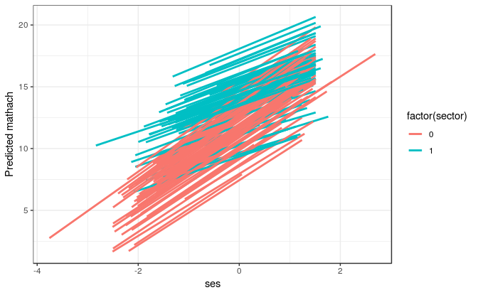

```r
# Get the predicted values for plotting from `lme4`
predict_crlv_int <- hsball %>% select(id, ses, sector) %>%  # include `sector`
  mutate(fit = predict(crlv_int))

ggplot(data = predict_crlv_int,
       aes(x = ses, y = fit, group = factor(id),
           color = factor(sector))) +   # use `sector` for coloring lines
  geom_smooth(method = "lm", se = FALSE) +
  labs(y = "Predicted mathach")
```

# Summaizing All Analyses in a Table

This can be done with the `texreg` package:

```r
texreg::screenreg(list(ran_int, m_lv2, contextual, ran_slp, crlv_int))
```

```
==================================================================================================
                         Model 1        Model 2        Model 3        Model 4        Model 5
--------------------------------------------------------------------------------------------------
(Intercept)                  12.64 ***      12.65 ***      12.66 ***      12.65 ***      12.18 ***
                             (0.24)         (0.15)         (0.15)         (0.15)         (0.20)
meanses                                      5.86 ***       3.68 ***       3.78 ***       3.13 ***
                                            (0.36)         (0.38)         (0.38)         (0.38)
ses                                                         2.19 ***       2.19 ***       2.78 ***
                                                           (0.11)         (0.12)         (0.14)
sector                                                                                    1.27 ***
                                                                                         (0.30)
sector:ses                                                                               -1.33 ***
                                                                                         (0.21)
--------------------------------------------------------------------------------------------------
AIC                       47122.79       46969.28       46578.58       46575.42       46532.05
BIC                       47143.43       46996.80       46612.98       46623.58       46593.97
Log Likelihood           -23558.40      -23480.64      -23284.29      -23280.71      -23257.03
Num. obs.                  7185           7185           7185           7185           7185
Num. groups: id             160            160            160            160            160
Var: id (Intercept)           8.61           2.64           2.69           2.70           2.34
Var: Residual                39.15          39.16          37.02          36.80          36.79
Var: id ses                                                                0.45           0.07
Cov: id (Intercept) ses                                                   -0.23           0.18
==================================================================================================
*** p < 0.001, ** p < 0.01, * p < 0.05
```